# UQoL Indicators in Barcelona 2026 - QCA

# 9. Visualisations

## 9.1 XY plots for sufficiency assessment

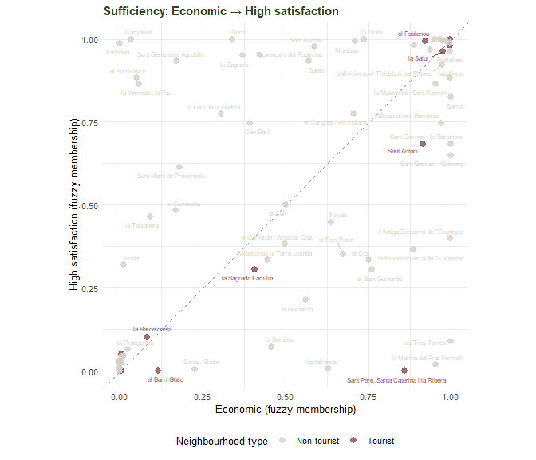

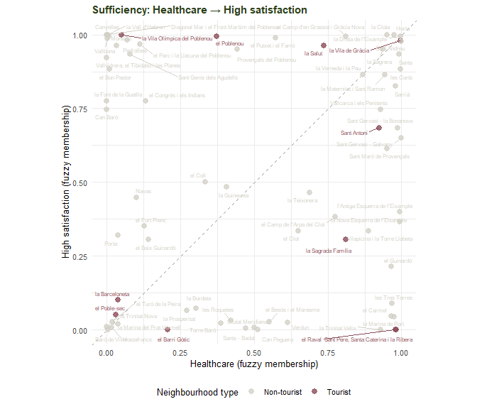

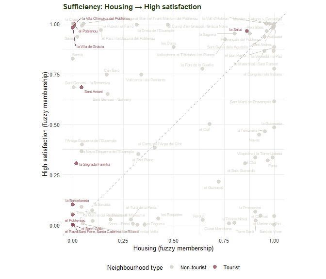

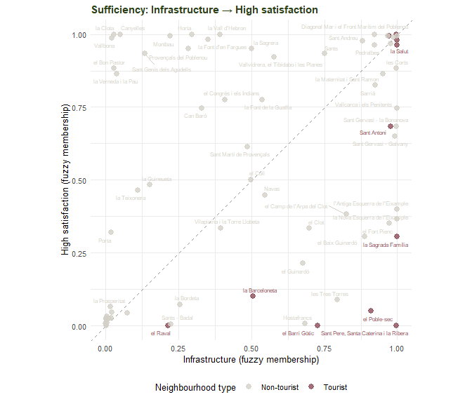

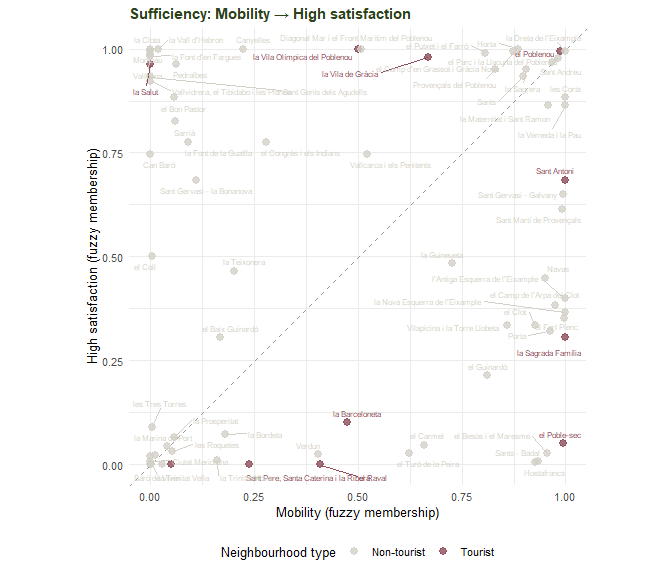

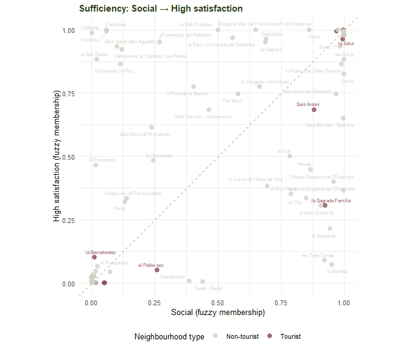

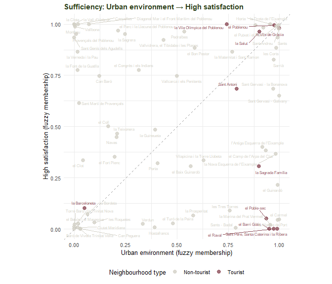

```r
# Define the colour palette consistent with the PCA notebook
palette_tour <- c("0" = "#D3D1C7", "1" = "#8C4D59")

cond_full_names <- c(
  ECON = "Economic", HLTH = "Healthcare", HOUS = "Housing",
  INFR = "Infrastructure", MOBI = "Mobility", SOCI = "Social",
  URBN = "Urban environment"
)

for (cond in cond_cols) {
  p <- ggplot(qca_data, aes_string(x = cond, y = "SATISF")) +
    geom_abline(slope = 1, intercept = 0,
                linetype = "dashed", colour = "grey60", linewidth = 0.5) +
    geom_point(aes(colour = factor(Tourism)),
               size = 2.5, alpha = 0.8) +
    geom_text_repel(aes(label = nom_barri, colour = factor(Tourism)),
                    size = 2, max.overlaps = 15, show.legend = FALSE) +
    scale_colour_manual(values = palette_tour,
                        labels = c("0" = "Non-tourist", "1" = "Tourist"),
                        name = "Neighbourhood type") +
    labs(x = paste(cond_full_names[cond], "(fuzzy membership)"),
         y = "High satisfaction (fuzzy membership)",
         title = paste("Sufficiency:", cond_full_names[cond],
                       "\u2192 High satisfaction")) +
    coord_fixed(ratio = 1, xlim = c(0, 1), ylim = c(0, 1)) +
    theme_minimal(base_family = "Arial", base_size = 10) +
    theme(
      plot.title = element_text(colour = "#2C4019", face = "bold", size = 11),
      legend.position = "bottom"
    )

  print(p)

  ggsave(filename = here("2_QCA", "Results", "Plots",
                          paste0("xy_high_", cond, ".png")),
         plot = p, width = 7, height = 6, dpi = 300)
}
```

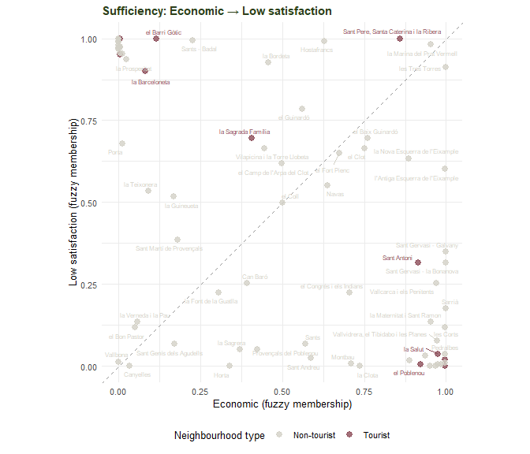

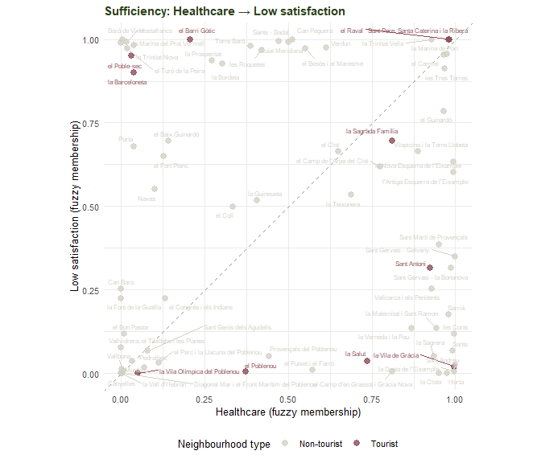

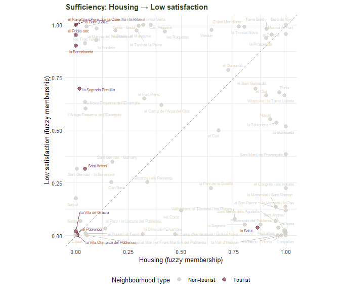

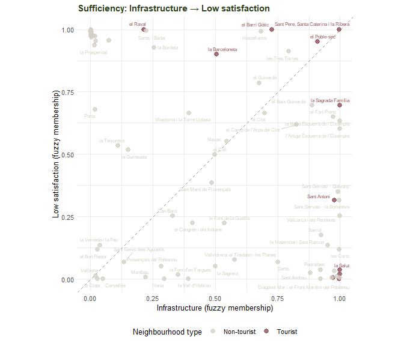

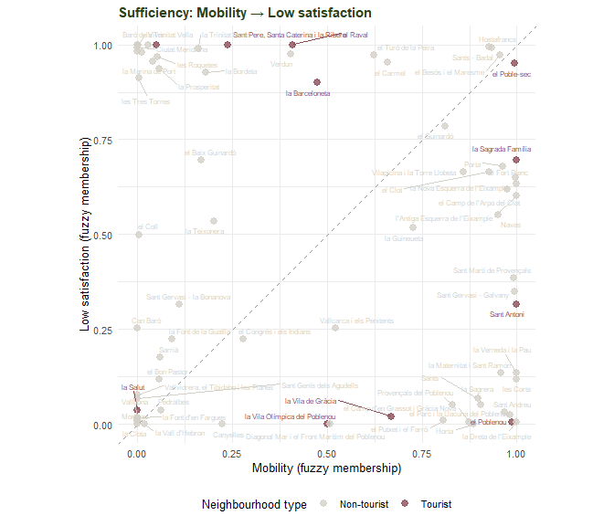

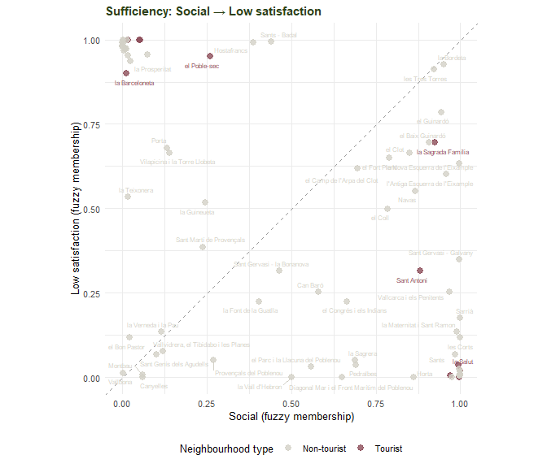

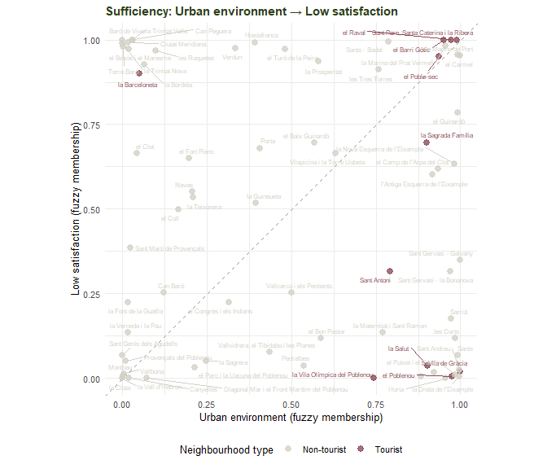

```r
for (cond in cond_cols) {
  p <- ggplot(qca_data, aes_string(x = cond, y = "SATISF_NEG")) +
    geom_abline(slope = 1, intercept = 0,
                linetype = "dashed", colour = "grey60", linewidth = 0.5) +
    geom_point(aes(colour = factor(Tourism)),
               size = 2.5, alpha = 0.8) +
    geom_text_repel(aes(label = nom_barri, colour = factor(Tourism)),
                    size = 2, max.overlaps = 15, show.legend = FALSE) +
    scale_colour_manual(values = palette_tour,
                        labels = c("0" = "Non-tourist", "1" = "Tourist"),
                        name = "Neighbourhood type") +
    labs(x = paste(cond_full_names[cond], "(fuzzy membership)"),
         y = "Low satisfaction (fuzzy membership)",
         title = paste("Sufficiency:", cond_full_names[cond],
                       "\u2192 Low satisfaction")) +
    coord_fixed(ratio = 1, xlim = c(0, 1), ylim = c(0, 1)) +
    theme_minimal(base_family = "Arial", base_size = 10) +
    theme(
      plot.title = element_text(colour = "#2C4019", face = "bold", size = 11),
      legend.position = "bottom"
    )

  print(p)

  ggsave(filename = here("2_QCA", "Results", "Plots",
                          paste0("xy_low_", cond, ".png")),
         plot = p, width = 7, height = 6, dpi = 300)
}
```

## 9.2 Satisfaction distribution by tourism status

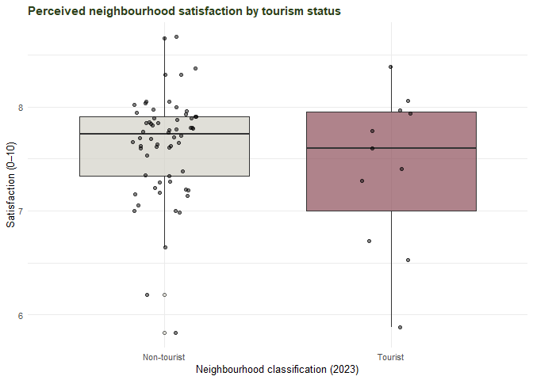

```r
p_box <- ggplot(qca_data, aes(x = factor(Tourism,
                                          labels = c("Non-tourist", "Tourist")),
                               y = satisfaction,
                               fill = factor(Tourism))) +
  geom_boxplot(alpha = 0.7, outlier.shape = 21) +
  geom_jitter(width = 0.15, alpha = 0.5, size = 1.5) +
  scale_fill_manual(values = c("0" = "#D3D1C7", "1" = "#8C4D59")) +
  labs(x = "Neighbourhood classification (2023)",
       y = "Satisfaction (0\u201310)",
       title = "Perceived neighbourhood satisfaction by tourism status") +
  theme_minimal(base_family = "Arial", base_size = 10) +
  theme(
    plot.title = element_text(colour = "#2C4019", face = "bold", size = 11),
    legend.position = "none"
  )

print(p_box)
```

```r
ggsave(filename = here("2_QCA", "Results", "Plots", "satisfaction_by_tourism.png"),
       plot = p_box, width = 7, height = 5, dpi = 300)
```

# 10. Robustness checks

Robustness checks assess the sensitivity of the results to alternative calibration thresholds and consistency cut-offs. This section tests two variations: (1) an alternative consistency threshold and (2) alternative calibration percentiles.

## 10.1 Sensitivity to consistency threshold

The main analysis uses a consistency cut-off of 0.80. Here, the analysis is repeated with a threshold of 0.75 and 0.85 to test whether the solution paths change.

```r
run_intermediate <- function(data, outcome, dir_exp,
                             incl_cut = incl_cut_main, pri_cut = pri_cut_main) {
  tt <- truthTable(data = data, outcome = outcome, conditions = cond_cols,
                   incl.cut = incl_cut, pri.cut = pri_cut, n.cut = 1,
                   complete = TRUE, show.cases = TRUE, sort.by = c("incl", "n"))
  tryCatch(
    minimize(tt, include = "?", details = TRUE, show.cases = TRUE,
             dir.exp = dir_exp, method = "eQMC", row.dom = FALSE, first.min = FALSE),
    error = function(e) { cat("  FAILED:", e$message, "\n"); NULL }
  )
}

robustness_specs <- list(
  list(label = "HIGH satisfaction", outcome = "SATISF",     dir_exp = dir_exp_high),
  list(label = "LOW satisfaction",  outcome = "SATISF_NEG", dir_exp = dir_exp_low)
)

for (spec in robustness_specs) {
  for (threshold in c(0.75, 0.85)) {
    cat("\n========================================\n")
    cat(" ", spec$label, "- consistency threshold:", threshold, "\n")
    cat("========================================\n")
    sol_rob <- run_intermediate(qca_data, spec$outcome, spec$dir_exp, incl_cut = threshold)
    if (!is.null(sol_rob)) print(sol_rob)
  }
}
```

```
========================================
  HIGH satisfaction - consistency threshold: 0.75
========================================

From C1P1:

M1:    ECON*HOUS + HOUS*INFR + ~INFR*SOCI + ECON*HLTH*SOCI*URBN + ECON*MOBI*SOCI*URBN + HLTH*HOUS*MOBI*~URBN
       -> SATISF

                         inclS   PRI   covS   covU   cases
--------------------------------------------------------------------------------------------------------
1             ECON*HOUS  0.882  0.826  0.390  0.041  42; 33,43,64; 38; 26; 25,35; 65; 8; 67; 23,24,37,62
2             HOUS*INFR  0.875  0.802  0.356  0.012  18; 63; 26; 25,35; 65; 8; 67; 23,24,37,62
3            ~INFR*SOCI  0.838  0.734  0.244  0.050  20,36; 45; 33,43,64; 38; 44
4   ECON*HLTH*SOCI*URBN  0.813  0.738  0.373  0.037  27,28; 6,9,13,14,15,22,30,31,32,34; 8; 23,24,37,62
5   ECON*MOBI*SOCI*URBN  0.829  0.761  0.357  0.036  10,11; 6,9,13,14,15,22,30,31,32,34; 23,24,37,62
6  HLTH*HOUS*MOBI*~URBN  0.796  0.621  0.155  0.039  72,73; 63; 67
--------------------------------------------------------------------------------------------------------
                     M1  0.799  0.735  0.742


From C1P2:

M1:    HOUS*INFR + ~INFR*SOCI + ECON*HOUS*~URBN + ECON*HLTH*SOCI*URBN + ECON*MOBI*SOCI*URBN +
       HLTH*HOUS*MOBI*~URBN -> SATISF

                         inclS   PRI   covS   covU   cases
-------------------------------------------------------------------------------------------------------
1             HOUS*INFR  0.875  0.802  0.356  0.030  18; 63; 26; 25,35; 65; 8; 67; 23,24,37,62
2            ~INFR*SOCI  0.838  0.734  0.244  0.057  20,36; 45; 33,43,64; 38; 44
3       ECON*HOUS*~URBN  0.897  0.811  0.240  0.029  42; 33,43,64; 26; 65; 67
4   ECON*HLTH*SOCI*URBN  0.813  0.738  0.373  0.037  27,28; 6,9,13,14,15,22,30,31,32,34; 8; 23,24,37,62
5   ECON*MOBI*SOCI*URBN  0.829  0.761  0.357  0.036  10,11; 6,9,13,14,15,22,30,31,32,34; 23,24,37,62
6  HLTH*HOUS*MOBI*~URBN  0.796  0.621  0.155  0.039  72,73; 63; 67
-------------------------------------------------------------------------------------------------------
                     M1  0.799  0.733  0.730


From C1P3:

```

[output cut: 420 more lines]

```

M1:    HLTH*~HOUS*~MOBI*~SOCI + ~HOUS*~INFR*~MOBI*~SOCI + ~ECON*~HLTH*~HOUS*~SOCI*URBN +
       ~ECON*HLTH*~INFR*~MOBI*~SOCI + ~ECON*~HOUS*~INFR*~SOCI*~URBN + ~ECON*HLTH*HOUS*~INFR*~SOCI*URBN
       -> SATISF_NEG

                                     inclS   PRI   covS   covU   cases
---------------------------------------------------------------------------------------
1            HLTH*~HOUS*~MOBI*~SOCI  0.934  0.908  0.162  0.031  49,59; 1; 4,29
2           ~HOUS*~INFR*~MOBI*~SOCI  0.906  0.876  0.211  0.026  52; 49,59; 1; 16
3      ~ECON*~HLTH*~HOUS*~SOCI*URBN  0.976  0.964  0.149  0.053  21; 2; 7
4      ~ECON*HLTH*~INFR*~MOBI*~SOCI  0.942  0.921  0.227  0.041  49,59; 1; 40,53,57; 17
5     ~ECON*~HOUS*~INFR*~SOCI*~URBN  0.913  0.884  0.198  0.024  52; 48; 49,59; 70
6  ~ECON*HLTH*HOUS*~INFR*~SOCI*URBN  0.939  0.895  0.153  0.034  17; 39,46
---------------------------------------------------------------------------------------
                                 M1  0.917  0.890  0.480
```

## 10.2 Sensitivity to calibration anchors

The main calibration uses 25th/50th/75th percentiles. Here, the conditions are recalibrated using 20th/50th/80th percentiles and the analysis is repeated.

```r
qca_data_alt <- qca_data

for (v in conditions) {
  qca_data_alt[[cond_labels[v]]] <- calibrate(
    qca_data[[v]], type = "fuzzy",
    thresholds = quantile(qca_data[[v]], c(0.20, 0.50, 0.80)))
}
qca_data_alt$SATISF <- calibrate(
  qca_data$satisfaction, type = "fuzzy",
  thresholds = quantile(qca_data$satisfaction, c(0.20, 0.50, 0.80)))

# 0.5 correction BEFORE computing the negated outcome
for (col in c("SATISF", cond_labels)) {
  qca_data_alt[[col]][qca_data_alt[[col]] == 0.5] <- 0.501
}
qca_data_alt$SATISF_NEG <- 1 - qca_data_alt$SATISF

for (spec in robustness_specs) {
  cat("\n=== ALTERNATIVE CALIBRATION (20/50/80) -", spec$label, "===\n")
  sol_alt <- run_intermediate(qca_data_alt, spec$outcome, spec$dir_exp)
  if (!is.null(sol_alt)) print(sol_alt)
}
```

```
=== ALTERNATIVE CALIBRATION (20/50/80) - HIGH satisfaction ===

From C1P1:

M1:    ECON*HOUS + HOUS*INFR + ECON*HLTH*~INFR*SOCI + ECON*HLTH*SOCI*URBN + HLTH*HOUS*MOBI*SOCI +
       HLTH*HOUS*MOBI*~URBN + ECON*INFR*MOBI*SOCI*URBN -> SATISF

                             inclS   PRI   covS   covU   cases
------------------------------------------------------------------------------------------------------------
1                 ECON*HOUS  0.896  0.830  0.417  0.053  42; 33,43,64; 38; 26; 25,35; 65; 8; 67; 23,24,37,62
2                 HOUS*INFR  0.890  0.808  0.378  0.006  18; 63; 26; 25,35; 65; 8; 67; 23,24,37,62
3      ECON*HLTH*~INFR*SOCI  0.882  0.721  0.163  0.019  44
4       ECON*HLTH*SOCI*URBN  0.820  0.724  0.395  0.033  27,28; 6,9,13,14,15,22,30,31,32,34; 8; 23,24,37,62
5       HLTH*HOUS*MOBI*SOCI  0.880  0.783  0.239  0.014  45; 63; 67; 23,24,37,62
6      HLTH*HOUS*MOBI*~URBN  0.801  0.581  0.174  0.030  72,73; 63; 67
7  ECON*INFR*MOBI*SOCI*URBN  0.838  0.750  0.386  0.036  10,11; 6,9,13,14,15,22,30,31,32,34; 23,24,37,62
------------------------------------------------------------------------------------------------------------
                         M1  0.812  0.736  0.740


From C1P2, C1P5, C1P6:

M1:    HOUS*INFR + ECON*HOUS*SOCI + ECON*HOUS*~URBN + HLTH*HOUS*MOBI*SOCI + HLTH*HOUS*MOBI*~URBN +
       ECON*HLTH*~INFR*SOCI*~URBN + ECON*HLTH*INFR*SOCI*URBN + ECON*INFR*MOBI*SOCI*URBN -> SATISF

                               inclS   PRI   covS   covU   cases
-------------------------------------------------------------------------------------------------------------
1                   HOUS*INFR  0.890  0.808  0.378  0.012  18; 63; 26; 25,35; 65; 8; 67; 23,24,37,62
2              ECON*HOUS*SOCI  0.890  0.808  0.353  0.012  33,43,64; 38; 25,35; 65; 8; 67; 23,24,37,62
3             ECON*HOUS*~URBN  0.914  0.822  0.273  0.026  42; 33,43,64; 26; 65; 67
4         HLTH*HOUS*MOBI*SOCI  0.880  0.783  0.239  0.014  45; 63; 67; 23,24,37,62
5        HLTH*HOUS*MOBI*~URBN  0.801  0.581  0.174  0.030  72,73; 63; 67
6  ECON*HLTH*~INFR*SOCI*~URBN  0.880  0.691  0.130  0.019  44
7    ECON*HLTH*INFR*SOCI*URBN  0.824  0.730  0.391  0.033  27,28; 6,9,13,14,15,22,30,31,32,34; 8; 23,24,37,62
8    ECON*INFR*MOBI*SOCI*URBN  0.838  0.750  0.386  0.036  10,11; 6,9,13,14,15,22,30,31,32,34; 23,24,37,62
-------------------------------------------------------------------------------------------------------------
                           M1  0.815  0.739  0.733


From C1P3, C1P8, C1P9:
```

[output cut: 105 more lines]

```

From C1P1, C1P2, C1P3, C1P4, C1P5, C1P6, C1P7, C1P8, C1P9, C1P10, C1P11, C1P12:

M1:    ~ECON*~HOUS + ~ECON*~INFR*~SOCI*URBN + ~HOUS*~MOBI*~SOCI*URBN + ~ECON*~HLTH*~INFR*MOBI*~SOCI +
       ~ECON*HLTH*~INFR*~MOBI*~SOCI -> SATISF_NEG

                                 inclS   PRI   covS   covU   cases
-----------------------------------------------------------------------------------------------------------
1                   ~ECON*~HOUS  0.898  0.856  0.404  0.139  52; 20,36; 48; 21; 3; 2; 7; 49,59; 1; 70; 5,66
2        ~ECON*~INFR*~SOCI*URBN  0.903  0.839  0.275  0.036  21; 54,61; 1; 17; 39,46
3        ~HOUS*~MOBI*~SOCI*URBN  0.926  0.884  0.191  0.058  2; 1; 16; 4,29
4  ~ECON*~HLTH*~INFR*MOBI*~SOCI  0.859  0.737  0.216  0.016  48; 21; 47,50,71
5  ~ECON*HLTH*~INFR*~MOBI*~SOCI  0.944  0.916  0.242  0.035  49,59; 1; 40,53,57; 17
-----------------------------------------------------------------------------------------------------------
                             M1  0.855  0.795  0.636
```

# 11. Calibrated data export

The full calibrated dataset is saved for reference and potential use in further analyses.

```r
# Select relevant columns for export
export_data <- qca_data %>%
  select(codi_barri, nom_barri, Tourism, satisfaction,
         Economic, Healthcare, Housing, Infrastructure, Mobility, Social, Urban,
         SATISF, SATISF_NEG, ECON, HLTH, HOUS, INFR, MOBI, SOCI, URBN)
write.csv2(export_data,
           file = here("2_QCA", "Results", "calibrated_qca_data.csv"),
           row.names = FALSE, quote = TRUE)

cat("Calibrated data saved.\n")
```

```
Calibrated data saved.
```

# 12. Session information

````r
# Capture session information to document the computational environment
session <- sessionInfo()

# Extract package names and versions from loaded packages
pkg_info <- sapply(session$otherPkgs, function(p) {
  paste0("- ", p$Package, " (", p$Version, ")")
})

# Build README content
readme_lines <- c(
  "# UQoL Indicators in Barcelona 2026 - QCA",
  "",
  "## Overview",
  paste("This repository contains the R Notebook used to perform a fuzzy-set",
        "Qualitative Comparative Analysis (fsQCA) on the composite UQoL dimension",
        "scores for Barcelona neighbourhoods. The analysis examines which configurations",
        "of UQoL dimensions, in combination with the tourism context, are associated with",
        "high and low perceived residential satisfaction. This analysis is part of a PhD",
        "dissertation examining the relationship between tourism impacts and urban quality",
        "of life."),
  "",
  "## Repository structure",
  "```",
  "\u251C\u2500\u2500 QCA_UQoL_Barcelona.Rmd                           # This notebook",
  "\u251C\u2500\u2500 ../1_PCA/Results/Aggregated/                     # Input data (from PCA step)",
  "\u2514\u2500\u2500 Results/                                        # Created automatically",
  "    \u251C\u2500\u2500 Calibration/",
  "    \u251C\u2500\u2500 Necessity/",
  "    \u251C\u2500\u2500 Sufficiency/",
  "    \u251C\u2500\u2500 Tourism_mapping/",
  "    \u2514\u2500\u2500 Plots/",
  "```",
  "",
  "## How to run",
  "1. Ensure the PCA notebook has been run first and the aggregated CSV is available.",
  "2. Place this notebook in the project directory (as a sibling to the `1_PCA` folder).",
  "3. Open the notebook in RStudio.",
  "4. Run all chunks in order (Ctrl+Alt+R / Cmd+Alt+R).",
  "5. All outputs are saved automatically under `Results/`.",
  "",
  "## Requirements",
  paste0("- R version: ",
         paste(session$R.version$major, session$R.version$minor, sep = ".")),
  "- The following packages are installed and loaded automatically if missing:",
  "",
  paste(sort(pkg_info), collapse = "\n"),
  "",
  "## Computational environment",
  paste0("- Platform: ", session$platform),
  paste0("- Operating system: ", session$running),
  paste0("- README generated: ", format(Sys.time(), "%Y-%m-%d %H:%M:%S")),
  "",
  "## Citation",
  "If you use or adapt this code, please cite the associated dissertation:",
  "[Author, Year, Title, Institution \u2014 to be completed before submission]"
)

# Write to README.md
writeLines(readme_lines, here("2_QCA", "README.md"))

cat("README.md created successfully.\n")
````

```
README.md created successfully.
```